# Bellabeat Case Study

Maritza Jimenez

2024-08-06

# Summary

Bellabeat, founded in 2013 by Urška Sršen and Sando Mur, is a tech-driven wellness company focused on women’s health. The company creates smart products that monitor activity, sleep, stress, and reproductive health, empowering women with valuable health insights. By 2016, Bellabeat had expanded globally, launching multiple products available through various online retailers and their own website. They invest in traditional and digital marketing, maintaining an active presence on Google Search, Facebook, Instagram, Twitter, YouTube, and the Google Display Network. Sršen has tasked the marketing analytics team with analyzing smart device usage data to uncover growth opportunities and refine their marketing strategy.

# Ask

### Identify the Business Task

The marketing team has been tasked with identifying trends in how consumers use non-Bellabeat smart devices to apply insights into Bellabeat’s marketing strategy.

Questions to take into consideration as we move through our analysis:

1. What are some trends in smart device usage?
2. How could these trends apply to Bellabeat customers?
3. How could these trends help influence Bellabeat marketing strategy?

### Consider Key Stakeholders

Key stakeholders are:

- Urška Sršen: Bellabeat’s cofounder and Chief Creative Officer
- Sando Mur: Mathematician and Bellabeat’s cofounder; key member of the Bellabeat executive team
- Bellabeat marketing analytics team: A team of data analysts responsible for collecting, analyzing, and reporting data that helps guide Bellabeat’s marketing strategy. You joined this team six months ago and have been busy learning about Bellabeat’s mission and business goals

# Prepare and Process

### Download data and store it properly

```r
library(dplyr)

daily_activity <- read.csv("dailyActivity_merged.csv")
sleep_day <- read.csv("sleepDay_Merged.csv")
```

### Clean up data time inconsistencies and rename columns

```r
daily_activity$ActivityDate=as.POSIXct(daily_activity$ActivityDate, format="%m/%d/%Y",
                                       tz=Sys.timezone())
daily_activity$date <- format(daily_activity$ActivityDate, format = "%m/%d/%y")

sleep_day$SleepDay=as.POSIXct(sleep_day$SleepDay, format="%m/%d/%Y %I:%M:%S %p",
                              tz=Sys.timezone())
sleep_day$date <- format(sleep_day$SleepDay, format = "%m/%d/%y")


daily_activity <- daily_activity %>%
                  dplyr::rename(Date = ActivityDate)

sleep_day <- sleep_day %>%
            dplyr::rename(Date = SleepDay)
```

### Identify how it’s organized

```r
n_distinct(daily_activity$Id)
```

```
## [1] 33
```

```r
n_distinct(sleep_day$Id)
```

```
## [1] 24
```

n_distict helps us identify how many participants we have in the data frames. daily_activity has 33 participants and sleep_day has 24. We will focus on the participants for which we have both daily_activity data and sleep_day data.

```r
daily_activity %>%
  dplyr::select(TotalSteps,
         TotalDistance,
         SedentaryMinutes, Calories) %>%
  summary()
```

```
##    TotalSteps    TotalDistance    SedentaryMinutes    Calories
##  Min.   :    0   Min.   : 0.000   Min.   :   0.0   Min.   :   0
##  1st Qu.: 3790   1st Qu.: 2.620   1st Qu.: 729.8   1st Qu.:1828
##  Median : 7406   Median : 5.245   Median :1057.5   Median :2134
##  Mean   : 7638   Mean   : 5.490   Mean   : 991.2   Mean   :2304
##  3rd Qu.:10727   3rd Qu.: 7.713   3rd Qu.:1229.5   3rd Qu.:2793
##  Max.   :36019   Max.   :28.030   Max.   :1440.0   Max.   :4900
```

```r
daily_activity %>%
  dplyr::select(VeryActiveMinutes, FairlyActiveMinutes, LightlyActiveMinutes) %>%
  summary()
```

```
##  VeryActiveMinutes FairlyActiveMinutes LightlyActiveMinutes
##  Min.   :  0.00    Min.   :  0.00      Min.   :  0.0
##  1st Qu.:  0.00    1st Qu.:  0.00      1st Qu.:127.0
##  Median :  4.00    Median :  6.00      Median :199.0
##  Mean   : 21.16    Mean   : 13.56      Mean   :192.8
##  3rd Qu.: 32.00    3rd Qu.: 19.00      3rd Qu.:264.0
##  Max.   :210.00    Max.   :143.00      Max.   :518.0
```

```r
sleep_day %>%
  dplyr::select(TotalSleepRecords, TotalMinutesAsleep, TotalTimeInBed) %>%
  summary()
```

```
##  TotalSleepRecords TotalMinutesAsleep TotalTimeInBed
##  Min.   :1.000     Min.   : 58.0      Min.   : 61.0
##  1st Qu.:1.000     1st Qu.:361.0      1st Qu.:403.0
##  Median :1.000     Median :433.0      Median :463.0
##  Mean   :1.119     Mean   :419.5      Mean   :458.6
##  3rd Qu.:1.000     3rd Qu.:490.0      3rd Qu.:526.0
##  Max.   :3.000     Max.   :796.0      Max.   :961.0
```

### Merge and organize data

```r
merged_df <- merge(sleep_day, daily_activity, by=c('Id', 'date'))
head(merged_df)
```

```
##           Id     date     Date.x TotalSleepRecords TotalMinutesAsleep
## 1 1503960366 04/12/16 2016-04-12                 1                327
## 2 1503960366 04/13/16 2016-04-13                 2                384
## 3 1503960366 04/15/16 2016-04-15                 1                412
## 4 1503960366 04/16/16 2016-04-16                 2                340
## 5 1503960366 04/17/16 2016-04-17                 1                700
## 6 1503960366 04/19/16 2016-04-19                 1                304
##   TotalTimeInBed     Date.y TotalSteps TotalDistance TrackerDistance
## 1            346 2016-04-12      13162          8.50            8.50
## 2            407 2016-04-13      10735          6.97            6.97
## 3            442 2016-04-15       9762          6.28            6.28
## 4            367 2016-04-16      12669          8.16            8.16
## 5            712 2016-04-17       9705          6.48            6.48
## 6            320 2016-04-19      15506          9.88            9.88
##   LoggedActivitiesDistance VeryActiveDistance ModeratelyActiveDistance
```

[output cut: 20 more lines]

### Determine the credibility of the data.

The data is open-source and appears to be mostly complete, with few missing variables. However, the limited number of participants may affect the generalizability of the findings. To enhance the robustness and reliability of the recommendations, it is advisable to acquire additional data from a more diverse and larger sample. Consequently, recommendations based on the current dataset should be interpreted with caution due to the small sample size.

# Analyze and Visualize

[figure not shown]

```r
ggplot(merged_df, aes(x = Calories, y = TotalSteps)) +
  geom_point() +
  geom_smooth(method = "lm", se = FALSE, color = "red") +
  labs(title = "Figure 1. Total Steps vs. Calories Burned", x = "Total Steps", y = "Calories") +
  theme_classic()
```

```r
overall_avg_sed_min <- merged_df %>%
  summarise(OverallAverageSedentaryMinutes = mean(SedentaryMinutes, na.rm = TRUE))


print(overall_avg_sed_min)
```

```
##   OverallAverageSedentaryMinutes
## 1                       712.1695
```

For all 24 participants the average Sedentary Minutes is 712. That’s nearly 12 hours! Due to the high sedentary minutes average we can assume that our audience likely have office jobs or lead relatively inactive lifestyles. We will need to take this into consideration when making our recommendations.

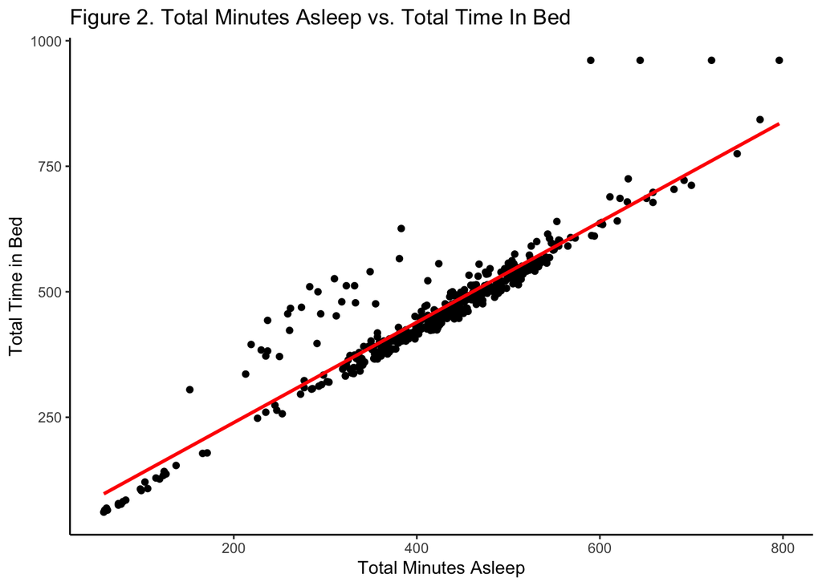

```r
ggplot(merged_df, aes(x =  TotalMinutesAsleep, y = TotalTimeInBed)) +
  geom_point() +
  geom_smooth(method = "lm", se = FALSE, color = "red") +
  labs(title = "Figure 2. Total Minutes Asleep vs. Total Time In Bed", x = "Total Minutes Asleep",
       y = "Total Time in Bed") +
  theme_classic()
```

```r
overall_total_min_asleep <- merged_df %>%
  summarise(OverallTotalMinAsleep = mean(TotalMinutesAsleep, na.rm = TRUE))
overall_total_min_asleep
```

```
##   OverallTotalMinAsleep
## 1              419.4673
```

```r
overall_total_time_in_bed <- merged_df %>%
  summarise(OverallTotalTimeInBed = mean(TotalTimeInBed, na.rm = TRUE))
overall_total_time_in_bed
```

```
##   OverallTotalTimeInBed
## 1              458.6392
```

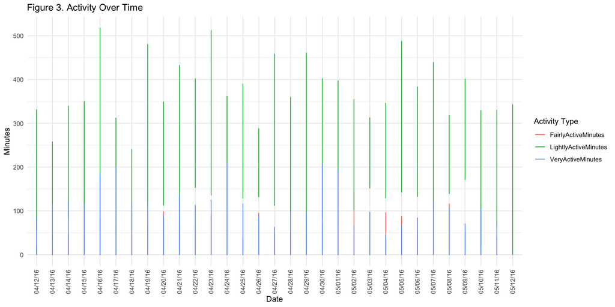

```r
library(tidyr)
activity_data_long <- merged_df %>%
  pivot_longer(cols = c(VeryActiveMinutes, LightlyActiveMinutes, FairlyActiveMinutes),
               names_to = "ActivityType", values_to = "Value")


ggplot(activity_data_long, aes(x = date, y = Value, color = ActivityType)) +
  geom_line() +
  labs(title = "Figure 3. Activity Over Time",
       x = "Date",
       y = "Minutes",
       color = "Activity Type") +
  theme_minimal() +
  theme(axis.text.x = element_text(angle = 90, vjust = 0.5, hjust = 1))
```

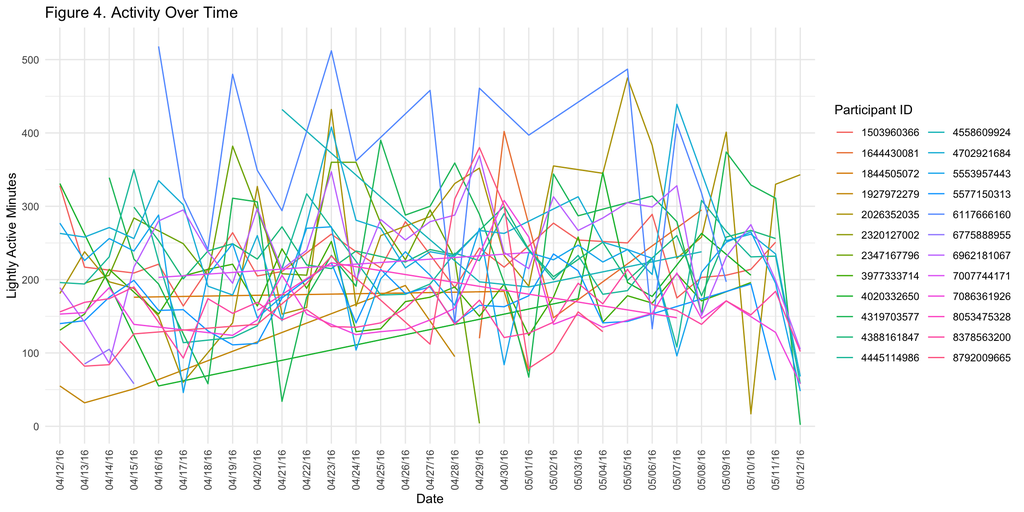

```r
ggplot(merged_df, aes(x = date, y = LightlyActiveMinutes, group = Id, color = as.factor(Id))) +
  geom_line() +
  labs(title = "Figure 4. Activity Over Time",
       x = "Date",
       y = "Lightly Active Minutes",
       color = "Participant ID") +
  theme_minimal() +
  theme(axis.text.x = element_text(angle = 90, vjust = 0.5, hjust = 1))
```

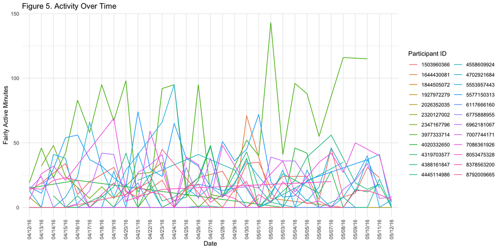

```r
ggplot(merged_df, aes(x = date, y = FairlyActiveMinutes, group = Id, color = as.factor(Id))) +
  geom_line() +
  labs(title = "Figure 5. Activity Over Time",
       x = "Date",
       y = "Fairly Active Minutes",
       color = "Participant ID") +
  theme_minimal() +
  theme(axis.text.x = element_text(angle = 90, vjust = 0.5, hjust = 1))
```

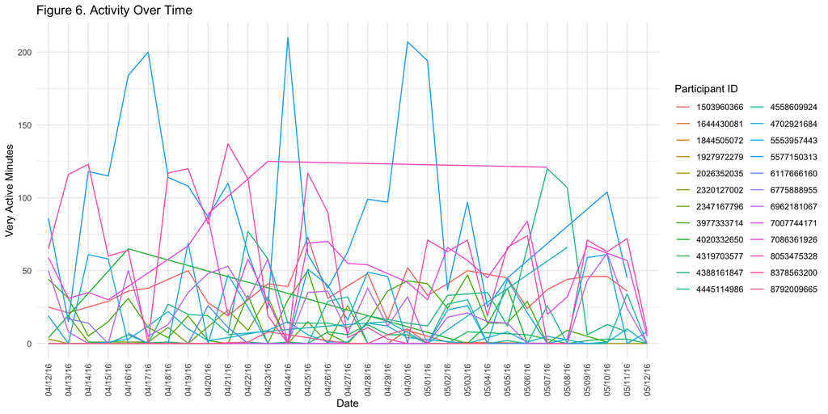

```r
ggplot(merged_df, aes(x = date, y = VeryActiveMinutes, group = Id, color = as.factor(Id))) +
  geom_line() +
  labs(title = "Figure 6. Activity Over Time",
       x = "Date",
       y = "Very Active Minutes",
       color = "Participant ID") +
  theme_minimal() +
  theme(axis.text.x = element_text(angle = 90, vjust = 0.5, hjust = 1))
```

```r
merged_df %>%
  dplyr::select(VeryActiveMinutes, FairlyActiveMinutes, LightlyActiveMinutes) %>%
  summary()
```

```
##  VeryActiveMinutes FairlyActiveMinutes LightlyActiveMinutes
##  Min.   :  0.00    Min.   :  0.00      Min.   :  2.0
##  1st Qu.:  0.00    1st Qu.:  0.00      1st Qu.:158.0
##  Median :  9.00    Median : 11.00      Median :208.0
##  Mean   : 25.19    Mean   : 18.04      Mean   :216.9
##  3rd Qu.: 38.00    3rd Qu.: 27.00      3rd Qu.:263.0
##  Max.   :210.00    Max.   :143.00      Max.   :518.0
```

Fig. 4-6 show that participants spend the majority of their active time in light activity, with an average of approximately 216 minutes and a median of 208 minutes. Fairly Active Minutes average around 18 minutes, with a median of 11 minutes, indicating that most individuals engage in moderate activity for less than 30 minutes. Very Active Minutes are lower, with an average of about 25 minutes and a median of 9 minutes, highlighting that high-intensity workouts are less common. The range for Lightly Active Minutes is broad, spanning from 2 to 518 minutes, while Very Active Minutes extend up to 210 minutes and Fairly Active Minutes up to 143 minutes. This suggests that most participants favor lower-intensity activities, with only a small fraction engaging in more vigorous exercise.

# Act

### What next? Recommendations!!

#### 1. Steps Challenge:

Since there is a positive correlation between total steps walked and calories burned, the Bellabeat app could launch a Steps Challenge to encourage participants to increase their daily steps. This challenge can motivate users to walk more, helping them achieve weight loss goals. Participants could be incentivized with prizes such as Bellabeat merchandise or products that support their health and fitness journey.

#### 3. Low-Intensity Workout Recommendations:

Considering the relatively inactive lifestyles of the participants, the Bellabeat app can offer tailored low-intensity workout recommendations. These workouts can be easily incorporated into their routines after a long workday, recognizing that participants are unlikely to transition directly into high-intensity exercises. By suggesting low-intensity activities, such as stretching, walking, or gentle yoga, the app can help participants gradually increase their activity levels. This approach aligns with their current habits, as data shows participants have nearly ten times more lightly active minutes compared to very active minutes. This strategy not only makes the transition smoother but also promotes sustainable long-term fitness habits.

#### 4. Recommendations based on a woman’s cycle:

Since Bellabeat focuses on women’s health, we can market a new feature where recommendations are tailored to a woman’s menstrual cycle (if applicable). For instance, on days with a heavy flow or symptoms like cramping, users can log their symptoms and receive personalized exercise recommendations based on their current needs.